# 16_미션_와인분류

## [미션] wine의 데이터셋이해

### 레드와인과 화이트 와인의 alcohol, sugar, PH의 관계 조사

- 이 자료의 class가 1이면 화이트 화인/0이면 레드와인임
- alcohol: 알콜농도
- sugar: 당도
- PH: 산도

## [미션] 자료 호출 및 합치기

###### #

### wine1=wine1.csv

### wine2=wine2.csv

###### #

```
['01_기술통계.ipynb',
 '02_이상치.ipynb',
 '03_선형회귀분석 회귀계수 및 절편값 구하기.ipynb',
 '04_회귀분석.ipynb',
 '05_선형회귀분석실습.ipynb',
 '06_이항분류함수.ipynb',
 '07_타이타닉데이터분석.ipynb',
 '08_와인데이터분석.ipynb',
 '09_공공데이터_코로나19_시도별현황.ipynb',
 '10_분류.ipynb',
 '11_SVM.ipynb',
 '12_금융데이터로 소득구간 예측하기.ipynb',
 '13_심부전증 분류예측.ipynb',
 '14_데이콘01_KBO_OPS.ipynb',
 '15_경사하강법.ipynb',
 '16_미션_와인분류 - 혼자한버전.ipynb',
 '16_미션_와인분류.ipynb',
 '17_서울시따릉이.ipynb',
 'data',
 'StartLr.sav',
 'submission.csv',
 '따릉이']
```

```
['data/21.09.17 학습자료\\wine1.csv', 'data/21.09.17 학습자료\\wine2.csv']
```

|  | index | alcohol | class |
| --- | --- | --- | --- |
| 0 | 7001 | 9.90 | 999.0 |
| 1 | 1 | 9.40 | 0.0 |
| 2 | 2 | 9.80 | 0.0 |
| 3 | 3 | 9.99 | 999.0 |
| 4 | 6498 | 9.80 | 0.0 |

|  | index | sugar_PH |
| --- | --- | --- |
| 0 | 7000 | 2.3/3.5 |
| 1 | 1 | 1.9/3.51 |
| 2 | 2 | 2.6/3.2 |
| 3 | 6498 | 2.3/3.26 |
| 4 | 4 | 1.9/3.16 |

###### #

### [두자료의 교집합 자료만 보기] 데이콘 경진대회 교재 P16 참조

### wine1과 wine2의 index 필드값이 같은 자료만 가져오기

### 최종 wine 변수에 할당

### wine['class']의 최대값1, 최소값 0 확인 (max, min 함수로 출력)

###### #

```
<class 'pandas.core.frame.DataFrame'>
RangeIndex: 6497 entries, 0 to 6496
Data columns (total 3 columns):
 #   Column   Non-Null Count  Dtype
---  ------   --------------  -----
 0   index    6497 non-null   int64
 1   alcohol  6497 non-null   float64
 2   class    6493 non-null   float64
dtypes: float64(2), int64(1)
memory usage: 152.4 KB
None
    index  alcohol  class
0       1      9.4    0.0
1       2      9.8    0.0
2       4      9.8    0.0
```

[output cut: 17 more lines]

|  | index | alcohol | class | sugar_PH |
| --- | --- | --- | --- | --- |
| 0 | 1 | 9.4 | 0.0 | 1.9/3.51 |
| 1 | 2 | 9.8 | 0.0 | 2.6/3.2 |
| 2 | 6498 | 9.8 | 0.0 | 2.3/3.26 |
| 3 | 4 | 9.8 | 0.0 | 1.9/3.16 |
| 4 | 5 | 9.4 | 0.0 | 1.9/3.51 |

```
(0.0, 1.0)
```

###### #

### wine자료와 wine2 자료를 연결하여서

### wine의 index번호에 해당하는

### wine2자료의 sugar_PH값 가져와 df 데이터셋 제작

### df 데이터셋의 sugar_PH의 값 분리하여

### df['sugar'] df['PH'] 변수로 작성

###### #

|  | index | alcohol | class | sugar_PH | sugar | PH |
| --- | --- | --- | --- | --- | --- | --- |
| 0 | 1 | 9.4 | 0.0 | 1.9/3.51 | 1.9 | 1.9 |
| 1 | 2 | 9.8 | 0.0 | 2.6/3.2 | 2.6 | 2.6 |
| 2 | 6498 | 9.8 | 0.0 | 2.3/3.26 | 2.3 | 2.3 |
| 3 | 4 | 9.8 | 0.0 | 1.9/3.16 | 1.9 | 1.9 |
| 4 | 5 | 9.4 | 0.0 | 1.9/3.51 | 1.9 | 1.9 |

```
[['1.9', '3.51'], ['2.6', '3.2'], ['2.3', '3.26'], ['1.9', '3.16'], ['1.9', '3.51'], ['1.8', '3.51'], ['1.6', '3.3'], ['1.2', '3.39'], ['2', '3.36'], ['6.1', '3.35']]
```

```
<class 'pandas.core.frame.DataFrame'>
Int64Index: 6497 entries, 0 to 6496
Data columns (total 6 columns):
 #   Column    Non-Null Count  Dtype
---  ------    --------------  -----
 0   index     6497 non-null   int64
 1   alcohol   6497 non-null   float64
 2   class     6493 non-null   float64
 3   sugar_PH  6497 non-null   object
 4   sugar     6497 non-null   object
 5   PH        6497 non-null   object
dtypes: float64(2), int64(1), object(3)
memory usage: 355.3+ KB
```

```
<class 'pandas.core.frame.DataFrame'>
Int64Index: 6497 entries, 0 to 6496
Data columns (total 4 columns):
 #   Column   Non-Null Count  Dtype
---  ------   --------------  -----
 0   alcohol  6497 non-null   float64
 1   class    6493 non-null   float64
 2   sugar    6497 non-null   object
 3   PH       6497 non-null   object
dtypes: float64(2), object(2)
memory usage: 253.8+ KB
```

|  | alcohol | class | sugar_PH |
| --- | --- | --- | --- |
| 0 | 9.4 | 0.0 | 1.9/3.51 |
| 1 | 9.8 | 0.0 | 2.6/3.2 |
| 2 | 9.8 | 0.0 | 2.3/3.26 |
| 3 | 9.8 | 0.0 | 1.9/3.16 |
| 4 | 9.4 | 0.0 | 1.9/3.51 |
| ... | ... | ... | ... |
| 6492 | 11.2 | 1.0 | 1.6/3.27 |
| 6493 | 9.6 | 1.0 | 8/3.15 |
| 6494 | 9.4 | 1.0 | 1.2/2.99 |
| 6495 | 12.8 | 1.0 | 1.1/3.34 |
| 6496 | 11.8 | 1.0 | 0.8/3.26 |

6497 rows × 3 columns

```
<class 'pandas.core.frame.DataFrame'>
Int64Index: 6497 entries, 0 to 6496
Data columns (total 3 columns):
 #   Column    Non-Null Count  Dtype
---  ------    --------------  -----
 0   alcohol   6497 non-null   float64
 1   class     6493 non-null   float64
 2   sugar_PH  6497 non-null   object
dtypes: float64(2), object(1)
memory usage: 203.0+ KB
```

```
<class 'pandas.core.frame.DataFrame'>
Int64Index: 6497 entries, 0 to 6496
Data columns (total 4 columns):
 #   Column   Non-Null Count  Dtype
---  ------   --------------  -----
 0   alcohol  6497 non-null   float64
 1   class    6493 non-null   float64
 2   sugar    6497 non-null   object
 3   PH       6497 non-null   object
dtypes: float64(2), object(2)
memory usage: 253.8+ KB
```

###### #

### df의 각 필드 타입 확인 및 데이터 갯수 확인

###### #

###### #

### sugar, PH의 필드형식 float64로 변환

###### #

```
<class 'pandas.core.frame.DataFrame'>
Int64Index: 6497 entries, 0 to 6496
Data columns (total 4 columns):
 #   Column   Non-Null Count  Dtype
---  ------   --------------  -----
 0   alcohol  6497 non-null   float64
 1   class    6493 non-null   float64
 2   sugar    6497 non-null   float64
 3   PH       6497 non-null   float64
dtypes: float64(4)
memory usage: 253.8 KB
```

```
[]
```

```
<class 'pandas.core.frame.DataFrame'>
Int64Index: 6497 entries, 0 to 6496
Data columns (total 4 columns):
 #   Column   Non-Null Count  Dtype
---  ------   --------------  -----
 0   alcohol  6497 non-null   float64
 1   class    6493 non-null   float64
 2   sugar    6497 non-null   float64
 3   PH       6497 non-null   float64
dtypes: float64(4)
memory usage: 253.8 KB
```

|  | alcohol | class | sugar | PH |
| --- | --- | --- | --- | --- |
| 0 | 9.4 | 0.0 | 1.9 | 3.51 |
| 1 | 9.8 | 0.0 | 2.6 | 3.20 |
| 2 | 9.8 | 0.0 | 2.3 | 3.26 |
| 3 | 9.8 | 0.0 | 1.9 | 3.16 |
| 4 | 9.4 | 0.0 | 1.9 | 3.51 |

```
<class 'pandas.core.frame.DataFrame'>
Int64Index: 6497 entries, 0 to 6496
Data columns (total 4 columns):
 #   Column   Non-Null Count  Dtype
---  ------   --------------  -----
 0   alcohol  6497 non-null   float64
 1   class    6493 non-null   float64
 2   sugar    6497 non-null   float64
 3   PH       6497 non-null   float64
dtypes: float64(4)
memory usage: 253.8 KB
```

```
alcohol    0
class      4
sugar      0
PH         0
dtype: int64
```

###### #

### [두자료의 교집합 자료만 보기] 데이콘 경진대회 교재 P37 참조

### 숫자값 필드 결측치 0으로 치환

###### #

[output not shown]

```
alcohol    0
class      0
sugar      0
PH         0
dtype: int64
```

```
alcohol    0
class      0
sugar      0
PH         0
dtype: int64
```

```
<class 'pandas.core.frame.DataFrame'>
Int64Index: 6497 entries, 0 to 6496
Data columns (total 4 columns):
 #   Column   Non-Null Count  Dtype
---  ------   --------------  -----
 0   alcohol  6497 non-null   float64
 1   class    6497 non-null   float64
 2   sugar    6497 non-null   float64
 3   PH       6497 non-null   float64
dtypes: float64(4)
memory usage: 253.8 KB
```

|  | alcohol | class | sugar | PH |
| --- | --- | --- | --- | --- |
| alcohol | 1.000000 | 0.032970 | -0.359415 | 0.121248 |
| class | 0.032970 | 1.000000 | 0.348821 | -0.329129 |
| sugar | -0.359415 | 0.348821 | 1.000000 | -0.267320 |
| PH | 0.121248 | -0.329129 | -0.267320 | 1.000000 |

## [미션] 집계 및 시각화

- 데이콘 경진대회 KBO자료의 시각화 도구 또는 다른 사이트 참조하여 시각화 도구에서 필요한 시각화를 진행하여 보세요.
- 기본: 히스토그램 / 산점도 / 박스플랏 / 상관도분석

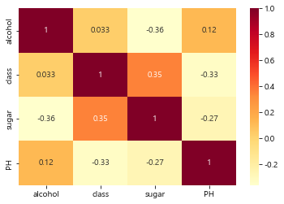

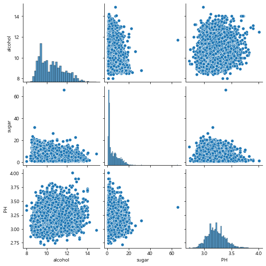

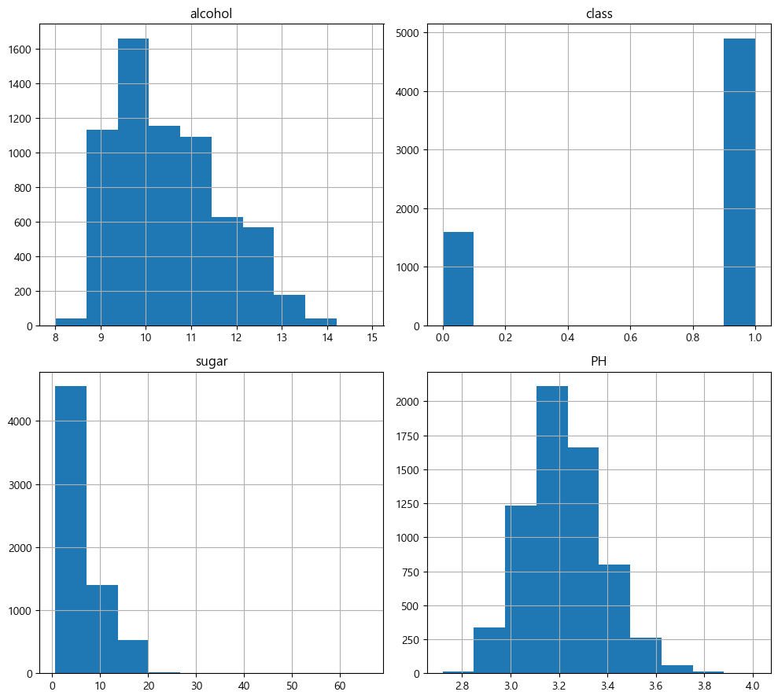

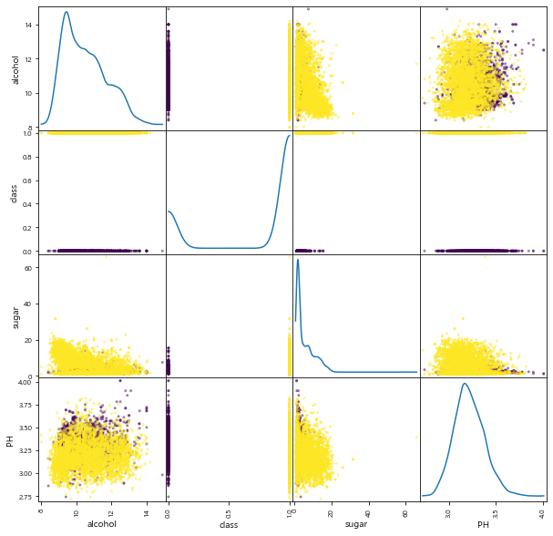

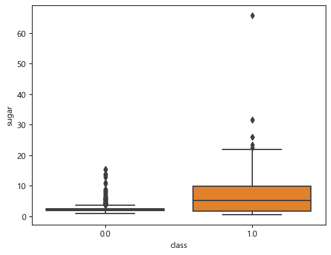

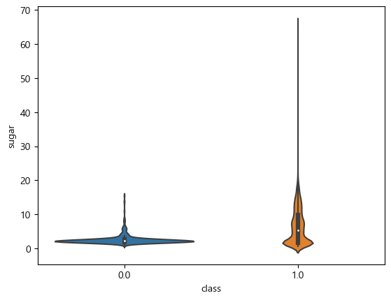

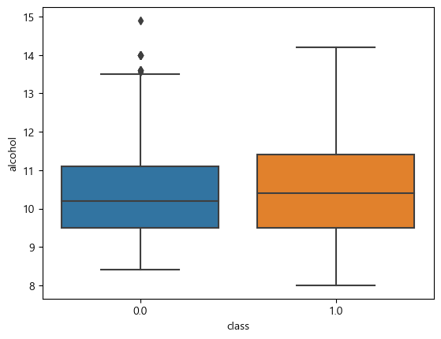

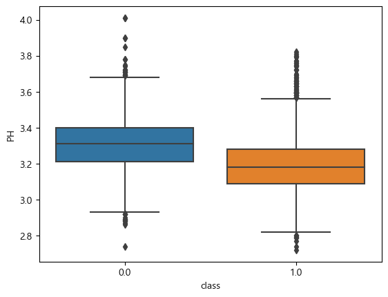

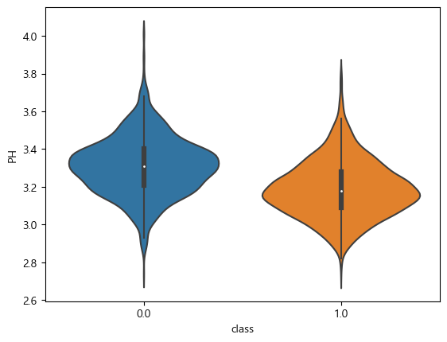

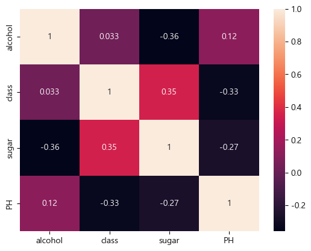

## [미션] x,y 데이터 분할

- class만 레이블(y값)으로 변환
- 그외는 특징값(X값임)

###### #

### y_data

### x_data

###### #

```
0       0.0
1       0.0
2       0.0
3       0.0
4       0.0
       ...
6492    1.0
6493    1.0
6494    1.0
6495    1.0
6496    1.0
Name: class, Length: 6497, dtype: float64
```

```
Index(['alcohol', 'class', 'sugar', 'PH'], dtype='object')
```

|  | alcohol | sugar | PH |
| --- | --- | --- | --- |
| 0 | 9.4 | 1.9 | 3.51 |
| 1 | 9.8 | 2.6 | 3.20 |
| 2 | 9.8 | 2.3 | 3.26 |
| 3 | 9.8 | 1.9 | 3.16 |
| 4 | 9.4 | 1.9 | 3.51 |
| ... | ... | ... | ... |
| 6492 | 11.2 | 1.6 | 3.27 |
| 6493 | 9.6 | 8.0 | 3.15 |
| 6494 | 9.4 | 1.2 | 2.99 |
| 6495 | 12.8 | 1.1 | 3.34 |
| 6496 | 11.8 | 0.8 | 3.26 |

6497 rows × 3 columns

|  | alcohol | sugar | PH |
| --- | --- | --- | --- |
| 0 | 9.4 | 1.9 | 3.51 |
| 1 | 9.8 | 2.6 | 3.20 |
| 2 | 9.8 | 2.3 | 3.26 |
| 3 | 9.8 | 1.9 | 3.16 |
| 4 | 9.4 | 1.9 | 3.51 |
| ... | ... | ... | ... |
| 6492 | 11.2 | 1.6 | 3.27 |
| 6493 | 9.6 | 8.0 | 3.15 |
| 6494 | 9.4 | 1.2 | 2.99 |
| 6495 | 12.8 | 1.1 | 3.34 |
| 6496 | 11.8 | 0.8 | 3.26 |

6497 rows × 3 columns

## [미션] 데이터 분할

- train_x, test_X, train_y, test_y로 분할 30%

###### #

### 사이킷런 제공 트레이닝 테스트 자료 분할기 사용

### train_x, test_X, train_y, test_y로 분할 30%

###### #

## [미션] 데이터 스케일러(표준화)

|  | alcohol | sugar | PH |
| --- | --- | --- | --- |
| 863 | -0.667324 | -0.615905 | 1.823293 |
| 104 | -0.920241 | -0.679157 | 0.697689 |
| 1764 | -0.583019 | 1.597904 | -0.365382 |
| 1691 | 1.777533 | -0.784576 | 0.259954 |
| 1344 | 0.428646 | -0.594821 | -0.803117 |
| ... | ... | ... | ... |
| 905 | -0.835935 | -0.510486 | 0.072353 |
| 5192 | 0.175730 | -0.257479 | 0.822756 |
| 3980 | -0.245797 | -0.067724 | 1.760760 |
| 235 | -1.257462 | -0.742409 | 0.947823 |
| 5157 | -1.257462 | 2.367466 | 0.134887 |

4547 rows × 3 columns

|  | alcohol | sugar | PH |
| --- | --- | --- | --- |
| 3772 | -1.070252 | 2.349458 | -0.421878 |
| 6009 | -0.628583 | 0.168122 | -0.667633 |
| 3464 | -0.242122 | 0.585602 | -0.606194 |
| 1518 | 0.006316 | -0.687714 | 0.622578 |
| 3761 | -0.904626 | -0.645966 | -2.756545 |
| ... | ... | ... | ... |
| 5044 | 1.331323 | 0.105499 | -0.176124 |
| 229 | 0.420381 | -0.604218 | 1.482718 |
| 5562 | 1.082884 | -0.353729 | 1.052648 |
| 4050 | -0.904626 | 0.940461 | 0.376823 |
| 1719 | -0.242122 | 0.042877 | 0.008192 |

1950 rows × 3 columns

## [미션] 로지스틱 회귀

- y class값의 고유값이 0과 1 두개임으로 단항 로지스틱 회귀가 사용됨.
- 로지스틱 회귀 분석에서 결과값이 0,1의 두가지는 시그모이드 함수가 실행되며
- 결과값이 0,1,2,3등 3개이상의 다항분류에서는 소프트맥스함수가 실행됨(추후 인공신경망에서 자세하게 학습)
- 로지스틱회귀분석의 옵션값 조정해봄
- 반복분류를 실행함으로 max_iter매개변수에서 반복횟수를 지정할수 있음. 기본은 100임.
- 로지스틱은 기본적으로 제공하는 리지(L2)규제를 사용함. 릿지에서는 alpha 매개변수로 규제의 양을 조정할수 있음.
- alpha가 커지면 규제가 커짐. 로지스틱회귀에서는 규제를 제어하는 변수가 C이며 C값이 작을수록 규제가 커짐. C의 기본값은 1임.

###### #

### 로지스틱 회귀 분석 실시

### 트레이닝, 테스트 스코어값

###### #

```
LogisticRegression()
```

```
0.7864526061139213
0.778974358974359
```

```
acc, 성공율 0.779
pre, 정밀도 0.824
rec, 재현율 0.903
```

```
0.778974358974359 0.22102564102564104
0.778974358974359
0.778974358974359
0.778974358974359
```

```
1.0
white wine
```

```
'white wine'
```

```
              precision    recall  f1-score   support

         0.0       0.55      0.38      0.45       462
         1.0       0.82      0.90      0.86      1488

    accuracy                           0.78      1950
   macro avg       0.69      0.64      0.66      1950
weighted avg       0.76      0.78      0.76      1950
```

```
              precision    recall  f1-score   support

         0.0       0.55      0.38      0.45       462
         1.0       0.82      0.90      0.86      1488

    accuracy                           0.78      1950
   macro avg       0.69      0.64      0.66      1950
weighted avg       0.76      0.78      0.76      1950
```

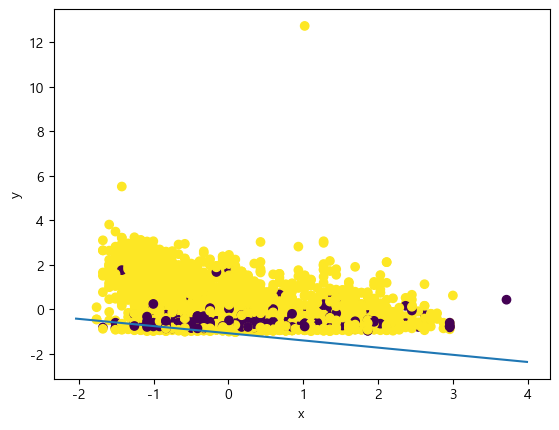

###### #

### w값(coef*), biase값(intercept*) 출력

###### #

```
array([[ 0.53757328,  1.66703606, -0.75473532]])
```

```
array([1.78100605])
```

## [실습 ]아래 작업내용에 대하여 이해해야 합니다.

### pvalue 값에 대하여 이해하세요

- 참고: 먼저 읽어보세요. https://3months.tistory.com/27
- 참고: https://rfriend.tistory.com/513 선형회귀 분석 자료도 있음.
- 참고: 회귀분석 https://mindscale.kr/course/basic-stat-r/collinearity/

### from statsmodels.formula.api import ols

- 참고: 회귀분석 http://doc.mindscale.kr/km/python/09.html

```
Optimization terminated successfully.
         Current function value: 0.603012
         Iterations 5
```

Logit Regression Results

| Dep. Variable: | class | No. Observations: | 4547 |
| --- | --- | --- | --- |
| Model: | Logit | Df Residuals: | 4544 |
| Method: | MLE | Df Model: | 2 |
| Date: | Sun, 19 Sep 2021 | Pseudo R-squ.: | -0.07222 |
| Time: | 13:22:59 | Log-Likelihood: | -2741.9 |
| converged: | True | LL-Null: | -2557.2 |
| Covariance Type: | nonrobust | LLR p-value: | 1.000 |

|  | coef | std err | z | P>\|z\| | [0.025 | 0.975] |
| --- | --- | --- | --- | --- | --- | --- |
| alcohol | 0.3909 | 0.036 | 10.961 | 0.000 | 0.321 | 0.461 |
| sugar | 0.7238 | 0.040 | 18.279 | 0.000 | 0.646 | 0.801 |
| PH | -0.5539 | 0.036 | -15.380 | 0.000 | -0.624 | -0.483 |

```
alcohol    1.478285
sugar      2.062197
PH         0.574701
dtype: float64
```

## [미션] 분류리포트와 혼돈행렬출력

```
LogisticRegression()
```

###### #

### 분류 리포트 출력

###### #

```
array([[ 176,  286],
       [ 145, 1343]], dtype=int64)
```

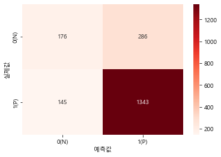

|  | 예측값(N) | 예측값(P) |
| --- | --- | --- |
| 실제값(N) | 176 | 286 |
| 실제값(P) | 145 | 1343 |

| 실제값/예측값 | y | y_hat |
| --- | --- | --- |
| 00 | 176 | 176 |
| 01 | 286 | 286 |
| 10 | 145 | 145 |
| 11 | 1343 | 1343 |

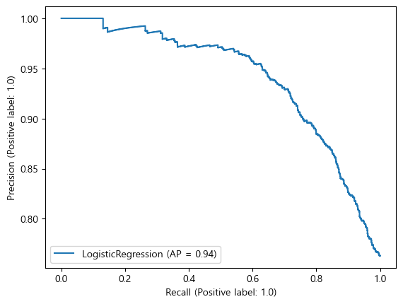

###### #

### 혼돈행렬 출력

###### #

[figure not shown]

## [실습 및 미션]

### 아래의 내용으로 임계값에 대하여 이해합니다.

```
array([[0.45006728, 0.54993272],
       [0.72549653, 0.27450347],
       [0.01382315, 0.98617685],
       [0.01522838, 0.98477162],
       [0.22096211, 0.77903789],
       [0.44766264, 0.55233736],
       [0.5607981 , 0.4392019 ],
       [0.37536908, 0.62463092],
       [0.01769616, 0.98230384],
       [0.11841417, 0.88158583]])
```

```
array([1., 0., 1., 1., 1., 1., 0., 1., 1., 1.])
```

```
1
0
1
1
1
1
0
1
1
1
```

```
array([1., 1., 1., ..., 1., 1., 1.])
```

```
pred_proba()결과 Shape : (1950, 2)
pred_proba array에서 앞 3개만 샘플로 추출
: [[0.0043177  0.9956823 ]
 [0.0973302  0.9026698 ]
 [0.04374767 0.95625233]]
두개의 class 중에서 더 큰 확률을 클래스 값으로 예측
 [[0.0043177  0.9956823  1.        ]
 [0.0973302  0.9026698  1.        ]
 [0.04374767 0.95625233 1.        ]]
```

```
------ custom_threshold_list----- 0.3
오차 행렬
[[  45  417]
 [  40 1448]]
 정밀도: 0.7764, 재현율: 0.9731
------ custom_threshold_list----- 0.5
오차 행렬
[[ 176  286]
 [ 145 1343]]
 정밀도: 0.8244, 재현율: 0.9026
------ custom_threshold_list----- 0.8
오차 행렬
[[411  51]
 [544 944]]
 정밀도: 0.9487, 재현율: 0.6344
------ custom_threshold_list----- 0.9
오차 행렬
[[ 452   10]
 [1009  479]]
 정밀도: 0.9796, 재현율: 0.3219
```

```
array([1, 1, 1, ..., 1, 1, 1])
```

###### #

### 오전에 제공한 김한용님 자료를 참고하여 또는 직접 수정하여서 분류리포트의 재현율및 정밀도등

### 필요한 값의 성능을 올려 봅니다.

###### #

```
LogisticRegression(solver='liblinear')
```

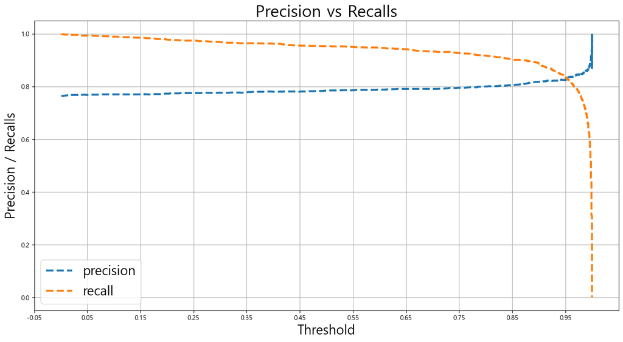

```
-------------------------- 임계값 : 0.4 -------------------------------
              precision    recall  f1-score   support

         0.0       0.51      0.13      0.20       462
         1.0       0.78      0.96      0.86      1488

    accuracy                           0.76      1950
   macro avg       0.65      0.55      0.53      1950
weighted avg       0.72      0.76      0.71      1950

-------------------------- 임계값 : 0.425 -------------------------------
              precision    recall  f1-score   support

         0.0       0.50      0.13      0.21       462
         1.0       0.78      0.96      0.86      1488

    accuracy                           0.76      1950
   macro avg       0.64      0.55      0.54      1950
weighted avg       0.71      0.76      0.71      1950

-------------------------- 임계값 : 0.45 -------------------------------
              precision    recall  f1-score   support

         0.0       0.48      0.14      0.21       462
         1.0       0.78      0.95      0.86      1488

    accuracy                           0.76      1950
   macro avg       0.63      0.55      0.54      1950
weighted avg       0.71      0.76      0.71      1950

-------------------------- 임계값 : 0.475 -------------------------------
              precision    recall  f1-score   support

         0.0       0.49      0.15      0.22       462
         1.0       0.78      0.95      0.86      1488

    accuracy                           0.76      1950
   macro avg       0.64      0.55      0.54      1950
weighted avg       0.71      0.76      0.71      1950

```

[output cut: 14 more lines]

```
         1.0       0.79      0.95      0.86      1488

    accuracy                           0.77      1950
   macro avg       0.65      0.56      0.55      1950
weighted avg       0.72      0.77      0.72      1950

-------------------------- 임계값 : 0.55 -------------------------------
              precision    recall  f1-score   support

         0.0       0.51      0.17      0.25       462
         1.0       0.79      0.95      0.86      1488

    accuracy                           0.76      1950
   macro avg       0.65      0.56      0.56      1950
weighted avg       0.72      0.76      0.72      1950
```

## [미션] 리지모델을 실행하여 봅니다.

###### #

## [미션] 라쏘모델을 실행하여 봅니다.

###### #

## [미션] 랜덤포레스트 모델을 실행하여 봅니다.

###### #

### 랜덤 포레스트모델 제작 및 실행

###### #

```
걸린시간 : 481.47초
```

## [미션] XGboost 모델을 실행하여 봅니다.

###### #

### XGboos포레스트모델 제작 및 실행

###### #

```
걸린시간 : 387.702초
```

## [실습] decision tree (의사 결정 트리 )

```
0.9973608972949197
0.8523076923076923
```

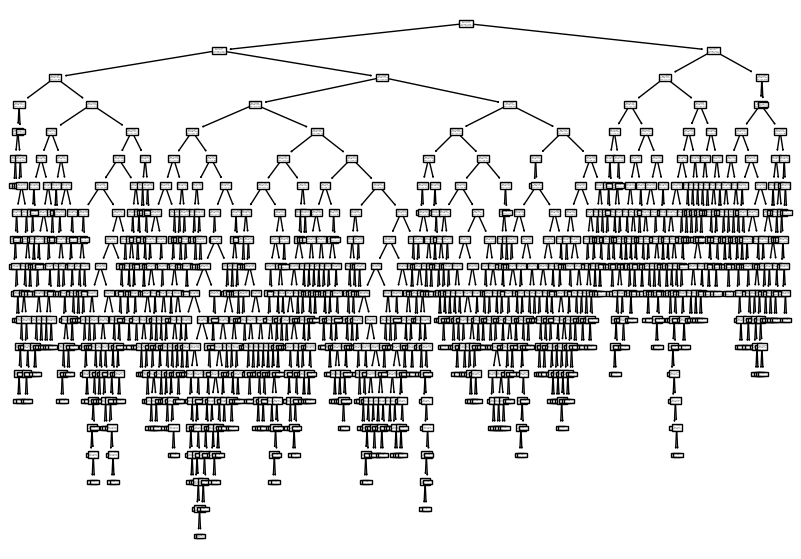

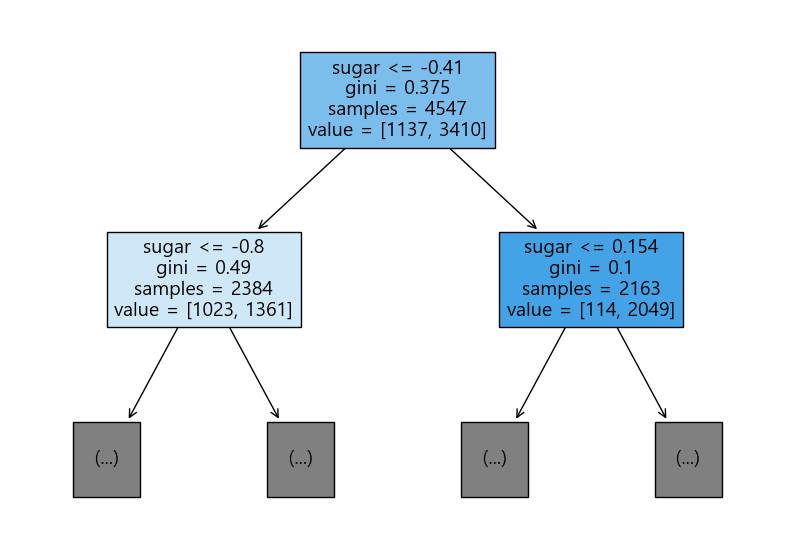

```
0.8484715196833077
0.8512820512820513
```

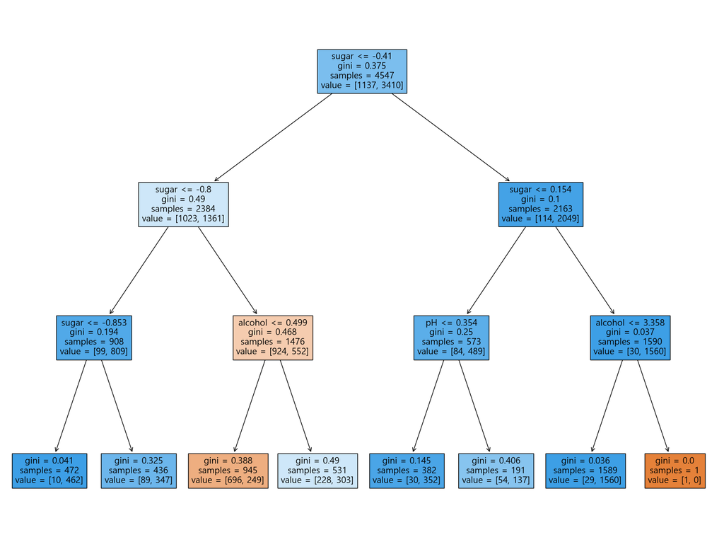

```
0.8484715196833077
0.8512820512820513
```

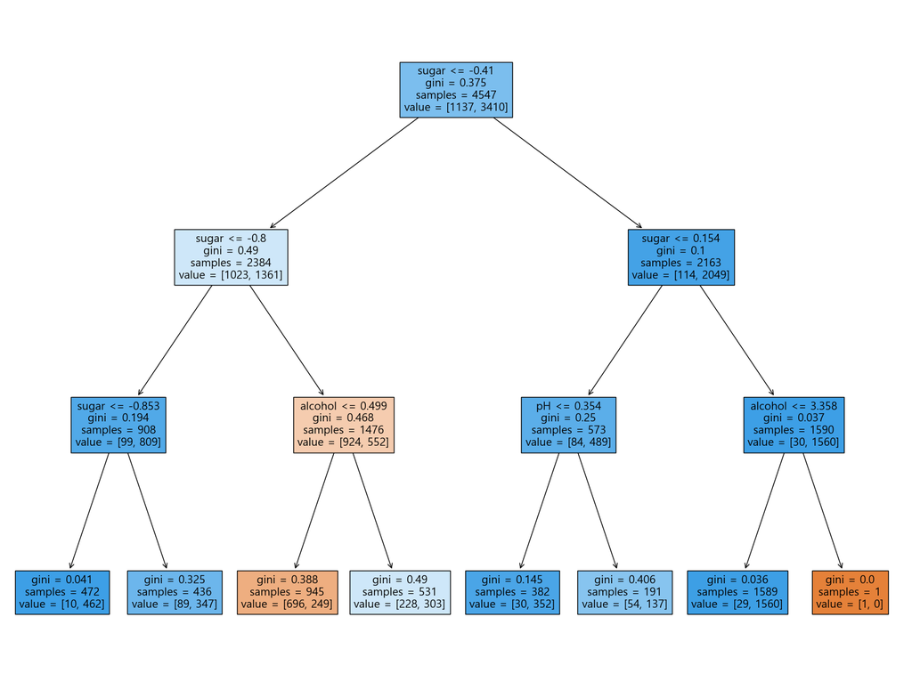

```
[0.09081547 0.89458869 0.01459584]
```

```
0.8832197053001979
0.862051282051282
```

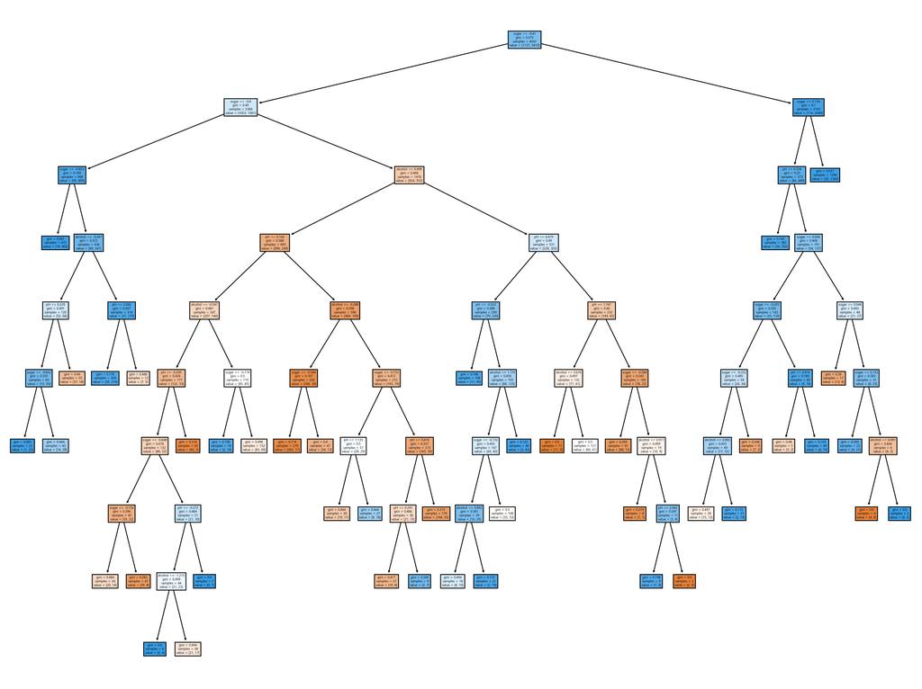